# How Do Annual Members And Casual Riders Use Cyclistic Bikes Differently

Omolewa Adetoro

2024-08-17

In this report we will look at the differences between in how annual members and casual riders use Cyclistic Bike. The data we will use was collected between the 1st September 2023 and 31st July 2024.

## Setting up my environment

Notes: setting up my R environment by loading the ” tidyverse”, “scales” and “bike_data_clean” csv file.

```r
library(tidyverse)
library(scales)
bike_data_clean = read.csv("~/Data Analysis Case Studies/Case Study 1 - How Does A Bike-Share Navigate Speedy Success/bike_data_clean.csv")
```

## Visualisation

Here we will look through a series of visualisations.

### Most common user type

Here, we plot a chart to determine what type of riders used the service the most.

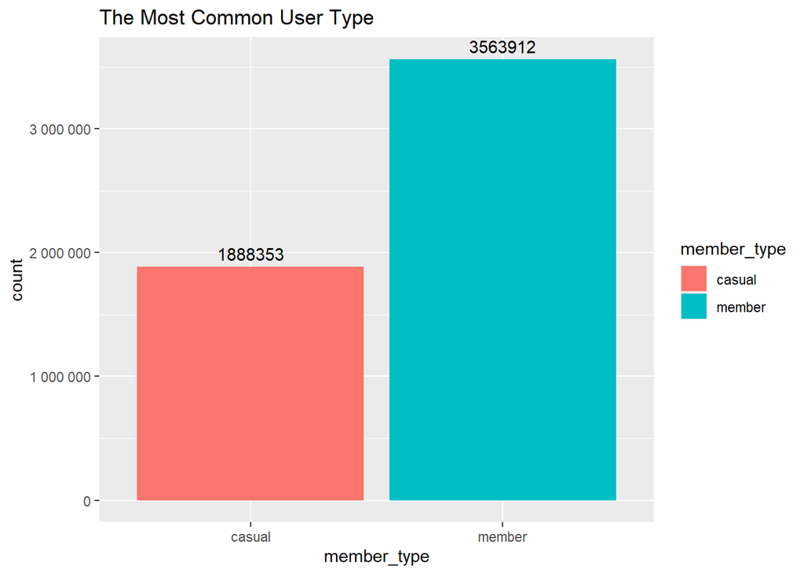

```r
ggplot(data = bike_data_clean) +
  geom_bar(mapping = aes(x = member_type, fill = member_type)) +
  labs(title = "The Most Common User Type") +
  geom_text(aes(x = member_type, label = after_stat(count)), stat = 'count', vjust = -0.5) +
  scale_y_continuous(labels = label_number())
```

### The type of bikes used by members and casual riders

Here, we will plot a chart to compare the types of bike used by annual members and casual riders.

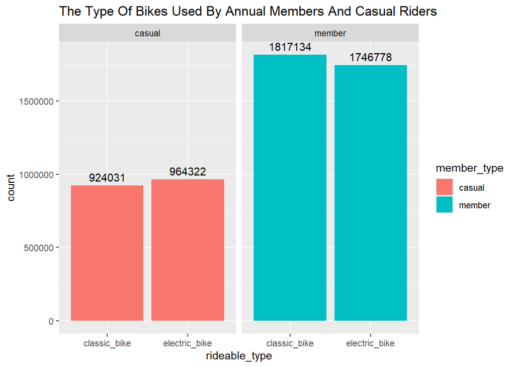

```r
ggplot(data = bike_data_clean) +
  geom_bar(mapping = aes(x = rideable_type, fill = member_type)) +
  facet_wrap(~ member_type) +
  labs(title = "The Type Of Bikes Used By Annual Members And Casual Riders") +
  geom_text(aes(x = rideable_type, label = after_stat(count)), stat = 'count', vjust = -0.5)
```

### Total rides for each week days by members and casual riders

Here, we will plot a chart to compare the total amount of rides taken for each weekday by annual members and casual riders.

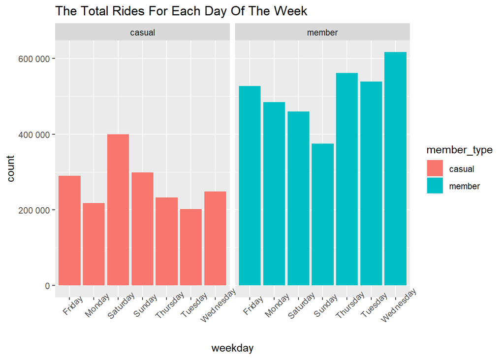

```r
ggplot(data = bike_data_clean) +
  geom_bar(mapping = aes(x = weekday, fill = member_type)) +
  facet_wrap(~ member_type) +
  labs(title = "The Total Rides For Each Day Of The Week") +
  theme(axis.text.x = element_text(angle = 45)) +
  scale_y_continuous(labels = label_number())
```

### Total rides for each month by members and casual riders

Here, we plot a chart to compare the monthly riders by members and casual riders

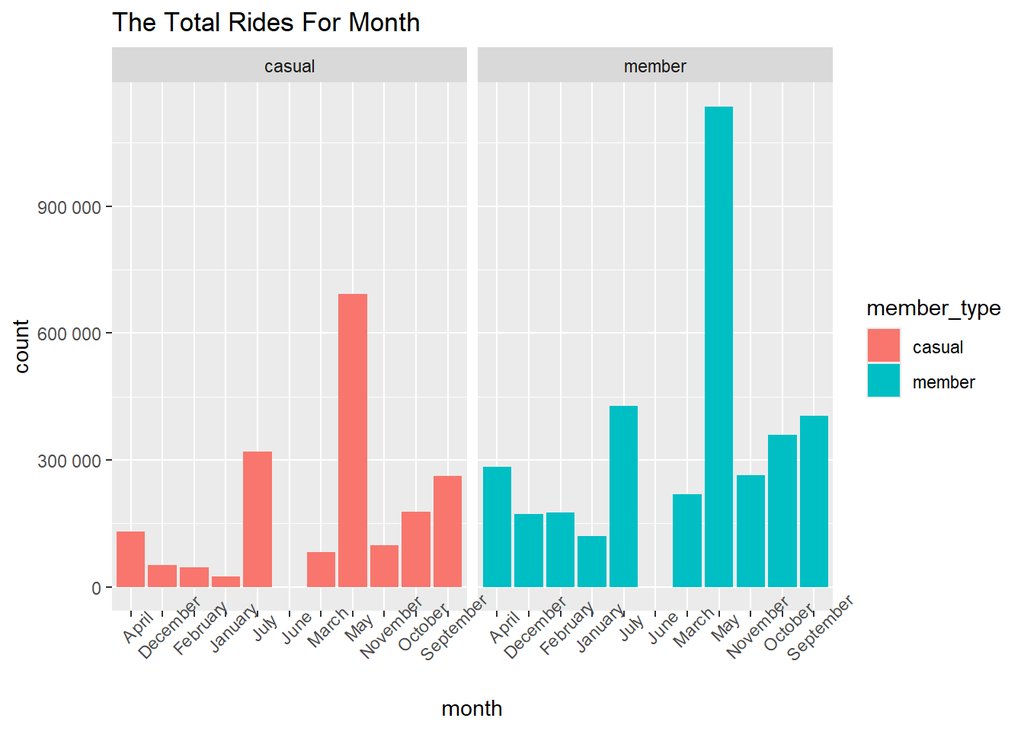

```r
ggplot(data = bike_data_clean) +
  geom_bar(mapping = aes(x = month, fill = member_type)) +
  facet_wrap(~ member_type) +
  labs(title = "The Total Rides For Month") +
  theme(axis.text.x = element_text(angle = 45)) +
  scale_y_continuous(labels = label_number())
```

## Findings

- Members far outnumber casual riders
- Casual riders show a slight preference for electric bikes, while members lean slightly towards classic bikes
- Casual riders are most active on Saturdays, whereas members prefer to ride on Wednesdays
- Both groups favor riding in May, with June being the month with the fewest rides

## Recommendations

- Given that members significantly outnumber casual riders, there is an opportunity to convert casual riders into members. Targeted outreach and promotions could help facilitate this transition
- Since casual riders prefer electric bikes while members favor classic bikes, adjusting bike availability to match these preferences can improve user satisfaction
- Increase the availability of electric bikes from Friday to Sunday, when casual riders are more active, while maintaining a steady supply of classic bikes during the rest of the week to cater to members
- Plan promotions on Saturdays to attract more casual riders, aligning with their peak activity days
- Introduce a special promotion in June to boost ridership during this slower month and help increase overall numbers.